# Housing Data Afer the 2007 Market Crash

Austin Huber

Due December 17, 2019

All packages used for the assignment can be found below:

```r
library(ggplot2)
library(DataComputing)
library(tidyr)
library(tidyverse)
library(dplyr)
library(lubridate)
library(readr)
library(mosaic)
```

## Research Question

**What factors impacted the recovery in different US States after the 2007-08 market crash? How have prices changed since then? Does location have any impact on the recovery of housing prices?**

## Data Access

Loading the data as a whole into a new variable in the RStudio environment. Here is the link of where the data was acquired from: https://www.zillow.com/research/data/

### House pricing dataset with 626 US Cities (2008-2019, monthly)

```
Number of rows:  626
Number of columns:  143
```

```r
head(Saleprices)
```

| RegionID | RegionName | SizeRank | 2008-03 | 2008-04 | 2008-05 | 2008-06 | 2008-07 | 2008-08 | 2008-09 | 2008-10 | 2008-11 | 2008-12 | 2009-01 | 2009-02 | 2009-03 | 2009-04 | 2009-05 | 2009-06 | 2009-07 | 2009-08 | 2009-09 | 2009-10 | 2009-11 | 2009-12 | 2010-01 | 2010-02 | 2010-03 | 2010-04 | 2010-05 | … |
| --- | --- | --- | --- | --- | --- | --- | --- | --- | --- | --- | --- | --- | --- | --- | --- | --- | --- | --- | --- | --- | --- | --- | --- | --- | --- | --- | --- | --- | --- | --- |
| 102001 | United States | 0 | 182900 | 179300 | 175300 | 172100 | 171000 | 170700 | 169900 | 168500 | 165800 | 162000 | 159800 | 158300 | 156800 | 152700 | 149100 | 148200 | 150000 | 152200 | 154100 | 155400 | 156800 | 157300 | 158700 | 159400 | 160300 | 157600 | 155200 | … |
| 394913 | New York, NY | 1 | NA | NA | NA | NA | NA | NA | NA | NA | NA | NA | NA | NA | NA | NA | NA | NA | NA | NA | NA | NA | NA | NA | NA | NA | NA | NA | NA | … |
| 753899 | Los Angeles-Long Beach-Anaheim, CA | 2 | 471300 | 459500 | 443100 | 432100 | 417900 | 405700 | 391300 | 379000 | 366600 | 355300 | 341300 | 331600 | 325000 | 319300 | 316200 | 322700 | 332800 | 341700 | 348100 | 353600 | 360400 | 362500 | 365300 | 363100 | 361300 | 357500 | 360300 | … |
| 394463 | Chicago, IL | 3 | 254400 | 249400 | 232900 | 220700 | 218600 | 219700 | 223900 | 223000 | 217800 | 212800 | 206400 | 205300 | 202100 | 195800 | 186800 | 180600 | 182000 | 186500 | 189900 | 192100 | 192500 | 192400 | 193000 | 195200 | 193500 | 189200 | 181900 | … |
| 394514 | Dallas-Fort Worth, TX | 4 | 145300 | 144000 | 142300 | 141900 | 144000 | 146000 | 146200 | 144200 | 142900 | 140900 | 140700 | 140600 | 141000 | 139500 | 139900 | 142200 | 145900 | 148100 | 148800 | 148100 | 147000 | 145300 | 145100 | 145500 | 146400 | 147200 | 145700 | … |
| 394974 | Philadelphia, PA | 5 | 212200 | 211900 | 207900 | 200000 | 196000 | 196100 | 198400 | 198200 | 199100 | 196200 | 195500 | 194400 | 198500 | 198900 | 194600 | 188900 | 185600 | 187600 | 189900 | 192000 | 194500 | 196900 | 199500 | 200700 | 201400 | 201800 | 196100 | … |

### House pricing dataset with 50 US States (2008-2019, monthly)

```
Number of rows:  50
Number of columns:  143
```

```r
head(SalePricesState)
```

| RegionID | RegionName | SizeRank | 2008-03 | 2008-04 | 2008-05 | 2008-06 | 2008-07 | 2008-08 | 2008-09 | 2008-10 | 2008-11 | 2008-12 | 2009-01 | 2009-02 | 2009-03 | 2009-04 | 2009-05 | 2009-06 | 2009-07 | 2009-08 | 2009-09 | 2009-10 | 2009-11 | 2009-12 | 2010-01 | 2010-02 | 2010-03 | 2010-04 | 2010-05 | … |
| --- | --- | --- | --- | --- | --- | --- | --- | --- | --- | --- | --- | --- | --- | --- | --- | --- | --- | --- | --- | --- | --- | --- | --- | --- | --- | --- | --- | --- | --- | --- |
| 9 | California | 1 | 393200 | 374200 | 352100 | 334900 | 320500 | 307000 | 293900 | 280300 | 266000 | 255200 | 243400 | 238200 | 230600 | 224400 | 219700 | 223400 | 232200 | 240200 | 246300 | 250400 | 255700 | 260500 | 264100 | 265000 | 263800 | 261300 | 263800 | … |
| 54 | Texas | 2 | 139600 | 139200 | 137600 | 137400 | 137700 | 139400 | 139500 | 139100 | 137000 | 134800 | 133700 | 134300 | 135900 | 136700 | 137500 | 139200 | 141200 | 142600 | 143000 | 142900 | 141900 | 140200 | 139400 | 139500 | 140800 | 141500 | 140200 | … |
| 43 | New York | 3 | NA | NA | NA | NA | NA | NA | NA | NA | NA | NA | NA | NA | NA | NA | NA | NA | NA | NA | NA | NA | NA | NA | NA | NA | NA | NA | NA | … |
| 14 | Florida | 4 | 203200 | 195300 | 189000 | 184300 | 181700 | 178100 | 173000 | 167100 | 162200 | 155800 | 149400 | 143800 | 138100 | 133100 | 127800 | 125400 | 126300 | 127300 | 128800 | 128300 | 129800 | 129700 | 129000 | 127400 | 125300 | 124300 | 121900 | … |
| 21 | Illinois | 5 | 204300 | 199100 | 185500 | 177500 | 174400 | 176400 | 177400 | 176400 | 173500 | 170600 | 165800 | 163100 | 158700 | 153900 | 148100 | 144000 | 145500 | 150800 | 155500 | 158000 | 157200 | 159100 | 161700 | 164100 | 160400 | 155700 | 151000 | … |
| 47 | Pennsylvania | 6 | 146700 | 145000 | 142800 | 139000 | 138900 | 140100 | 141100 | 139800 | 136800 | 134700 | 134100 | 135100 | 137300 | 137500 | 136700 | 135500 | 135200 | 137000 | 139100 | 140200 | 141800 | 142800 | 142300 | 141800 | 142500 | 144000 | 142900 | … |

## Wrangling

I decided to create 4 different data sets, with 3 of them being used for graphics. These 3 include: US mean, max, and min prices for every month, the mean, max, and min prices per state for every month, and the US mean, max, and min prices per top 626 cities for every month. There is also an additional dataset for the 4th graphic, but this required many different calculations and operations so that dataset is down with the graphic.

```r
# Isolates just the months and their data by removing first 3 columns
JustMonths <- Saleprices[-c(1,2,3)]
JustMonthsState <- SalePricesState[-c(1,2,3)]

# Creates the applyFunction to be used by 3 different data frames
applyFun <- function(set,num,fun){
  return(apply(set,num,fun,na.rm=TRUE))
}

# Creates a dataset of minimum, maximum, and mean values for each month, from the city data
MonthlyCalcs <- data.frame("month"=colnames(JustMonths),"Min"=applyFun(JustMonths,2,min),"Max"=applyFun(JustMonths,2,max),"Mean"=applyFun(JustMonths,2,mean))
head(MonthlyCalcs)
```

|  | month | Min | Max | Mean |
| --- | --- | --- | --- | --- |
| 2008-03 | 2008-03 | 57800 | 676400 | 187775.3 |
| 2008-04 | 2008-04 | 58200 | 643200 | 184604.9 |
| 2008-05 | 2008-05 | 58600 | 618700 | 179988.3 |
| 2008-06 | 2008-06 | 59500 | 600500 | 176948.7 |
| 2008-07 | 2008-07 | 59700 | 585200 | 174984.8 |
| 2008-08 | 2008-08 | 55500 | 565400 | 173192.3 |

```r
# This is the average data for all of the United States in a narrow format
USdata <- Saleprices %>% filter(RegionID==102001) %>% gather(month, price, -RegionID, -RegionName, -SizeRank)
USExtensiveData <- USdata %>% left_join(MonthlyCalcs, by=c("month"="month"))
```

```
Column `month` joining character vector and factor, coercing into character vector
```

```r
head(USExtensiveData)
```

| RegionID | RegionName | SizeRank | month | price | Min | Max | Mean |
| --- | --- | --- | --- | --- | --- | --- | --- |
| 102001 | United States | 0 | 2008-03 | 182900 | 57800 | 676400 | 187775.3 |
| 102001 | United States | 0 | 2008-04 | 179300 | 58200 | 643200 | 184604.9 |
| 102001 | United States | 0 | 2008-05 | 175300 | 58600 | 618700 | 179988.3 |
| 102001 | United States | 0 | 2008-06 | 172100 | 59500 | 600500 | 176948.7 |
| 102001 | United States | 0 | 2008-07 | 171000 | 59700 | 585200 | 174984.8 |
| 102001 | United States | 0 | 2008-08 | 170700 | 55500 | 565400 | 173192.3 |

```r
# This data set contains the minimum, maximum, and mean values for each state over all the months
MinMaxMeanPerState <-
  SalePricesState %>%
  mutate(MinimumPrice = applyFun(JustMonthsState,1,min)) %>%
  mutate(MaximumPrice = applyFun(JustMonthsState,1,max)) %>%
  mutate(MeanPrice = applyFun(JustMonthsState,1,mean)) %>%
  mutate(Difference = MaximumPrice-MinimumPrice)
head(MinMaxMeanPerState)
```

| RegionID | RegionName | SizeRank | 2008-03 | 2008-04 | 2008-05 | 2008-06 | 2008-07 | 2008-08 | 2008-09 | 2008-10 | 2008-11 | 2008-12 | 2009-01 | 2009-02 | 2009-03 | 2009-04 | 2009-05 | 2009-06 | 2009-07 | 2009-08 | 2009-09 | 2009-10 | 2009-11 | 2009-12 | 2010-01 | 2010-02 | 2010-03 | 2010-04 | 2010-05 | … |
| --- | --- | --- | --- | --- | --- | --- | --- | --- | --- | --- | --- | --- | --- | --- | --- | --- | --- | --- | --- | --- | --- | --- | --- | --- | --- | --- | --- | --- | --- | --- |
| 9 | California | 1 | 393200 | 374200 | 352100 | 334900 | 320500 | 307000 | 293900 | 280300 | 266000 | 255200 | 243400 | 238200 | 230600 | 224400 | 219700 | 223400 | 232200 | 240200 | 246300 | 250400 | 255700 | 260500 | 264100 | 265000 | 263800 | 261300 | 263800 | … |
| 54 | Texas | 2 | 139600 | 139200 | 137600 | 137400 | 137700 | 139400 | 139500 | 139100 | 137000 | 134800 | 133700 | 134300 | 135900 | 136700 | 137500 | 139200 | 141200 | 142600 | 143000 | 142900 | 141900 | 140200 | 139400 | 139500 | 140800 | 141500 | 140200 | … |
| 43 | New York | 3 | NA | NA | NA | NA | NA | NA | NA | NA | NA | NA | NA | NA | NA | NA | NA | NA | NA | NA | NA | NA | NA | NA | NA | NA | NA | NA | NA | … |
| 14 | Florida | 4 | 203200 | 195300 | 189000 | 184300 | 181700 | 178100 | 173000 | 167100 | 162200 | 155800 | 149400 | 143800 | 138100 | 133100 | 127800 | 125400 | 126300 | 127300 | 128800 | 128300 | 129800 | 129700 | 129000 | 127400 | 125300 | 124300 | 121900 | … |
| 21 | Illinois | 5 | 204300 | 199100 | 185500 | 177500 | 174400 | 176400 | 177400 | 176400 | 173500 | 170600 | 165800 | 163100 | 158700 | 153900 | 148100 | 144000 | 145500 | 150800 | 155500 | 158000 | 157200 | 159100 | 161700 | 164100 | 160400 | 155700 | 151000 | … |
| 47 | Pennsylvania | 6 | 146700 | 145000 | 142800 | 139000 | 138900 | 140100 | 141100 | 139800 | 136800 | 134700 | 134100 | 135100 | 137300 | 137500 | 136700 | 135500 | 135200 | 137000 | 139100 | 140200 | 141800 | 142800 | 142300 | 141800 | 142500 | 144000 | 142900 | … |

```r
# This data set contains the minimum, maximum, and mean values for each city over all the months
MinMaxMeanPerCity <-
  Saleprices %>%
  mutate(MinimumPrice = applyFun(JustMonths,1,min)) %>%
  mutate(MaximumPrice = applyFun(JustMonths,1,max)) %>%
  mutate(MeanPrice = applyFun(JustMonths,1,mean))
head(MinMaxMeanPerCity)
```

| RegionID | RegionName | SizeRank | 2008-03 | 2008-04 | 2008-05 | 2008-06 | 2008-07 | 2008-08 | 2008-09 | 2008-10 | 2008-11 | 2008-12 | 2009-01 | 2009-02 | 2009-03 | 2009-04 | 2009-05 | 2009-06 | 2009-07 | 2009-08 | 2009-09 | 2009-10 | 2009-11 | 2009-12 | 2010-01 | 2010-02 | 2010-03 | 2010-04 | 2010-05 | … |
| --- | --- | --- | --- | --- | --- | --- | --- | --- | --- | --- | --- | --- | --- | --- | --- | --- | --- | --- | --- | --- | --- | --- | --- | --- | --- | --- | --- | --- | --- | --- |
| 102001 | United States | 0 | 182900 | 179300 | 175300 | 172100 | 171000 | 170700 | 169900 | 168500 | 165800 | 162000 | 159800 | 158300 | 156800 | 152700 | 149100 | 148200 | 150000 | 152200 | 154100 | 155400 | 156800 | 157300 | 158700 | 159400 | 160300 | 157600 | 155200 | … |
| 394913 | New York, NY | 1 | NA | NA | NA | NA | NA | NA | NA | NA | NA | NA | NA | NA | NA | NA | NA | NA | NA | NA | NA | NA | NA | NA | NA | NA | NA | NA | NA | … |
| 753899 | Los Angeles-Long Beach-Anaheim, CA | 2 | 471300 | 459500 | 443100 | 432100 | 417900 | 405700 | 391300 | 379000 | 366600 | 355300 | 341300 | 331600 | 325000 | 319300 | 316200 | 322700 | 332800 | 341700 | 348100 | 353600 | 360400 | 362500 | 365300 | 363100 | 361300 | 357500 | 360300 | … |
| 394463 | Chicago, IL | 3 | 254400 | 249400 | 232900 | 220700 | 218600 | 219700 | 223900 | 223000 | 217800 | 212800 | 206400 | 205300 | 202100 | 195800 | 186800 | 180600 | 182000 | 186500 | 189900 | 192100 | 192500 | 192400 | 193000 | 195200 | 193500 | 189200 | 181900 | … |
| 394514 | Dallas-Fort Worth, TX | 4 | 145300 | 144000 | 142300 | 141900 | 144000 | 146000 | 146200 | 144200 | 142900 | 140900 | 140700 | 140600 | 141000 | 139500 | 139900 | 142200 | 145900 | 148100 | 148800 | 148100 | 147000 | 145300 | 145100 | 145500 | 146400 | 147200 | 145700 | … |
| 394974 | Philadelphia, PA | 5 | 212200 | 211900 | 207900 | 200000 | 196000 | 196100 | 198400 | 198200 | 199100 | 196200 | 195500 | 194400 | 198500 | 198900 | 194600 | 188900 | 185600 | 187600 | 189900 | 192000 | 194500 | 196900 | 199500 | 200700 | 201400 | 201800 | 196100 | … |

## Visualizations

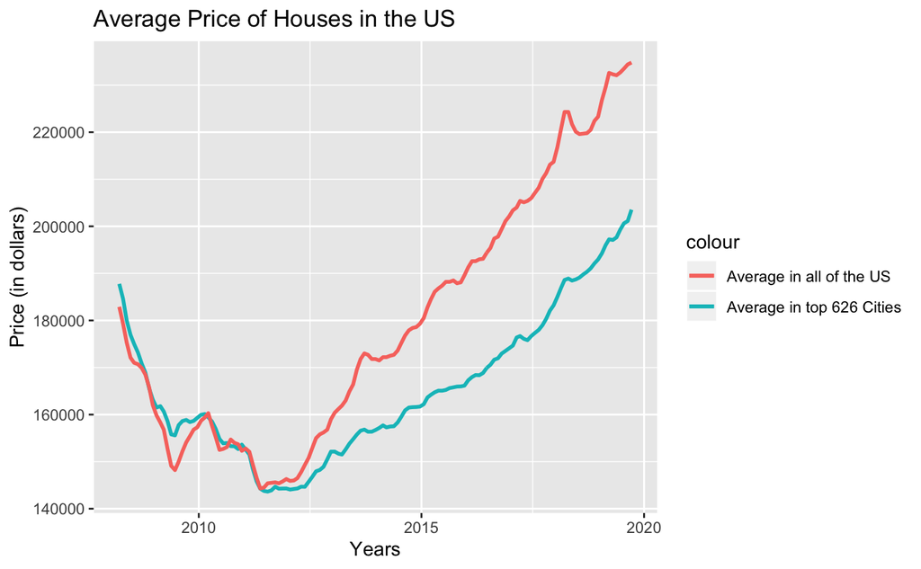

```r
USExtensiveData %>%
  mutate(month = lubridate::dym(month)) %>%
  filter(month!="2019-10-20") %>%
  ggplot(aes(x=month,y=Mean,color="Average in top 626 Cities"))+geom_line(size=1)+geom_line(mapping=aes(y=price,color="Average in all of the US"),size=1)+ggtitle("Average Price of Houses in the US")+xlab("Years")+ylab("Price (in dollars)")
```

This graphic above shows 2 different lines, one line shows the average house prices of all houses in the entire US, the other shows the average house price of the top 626 cities in the US. What this graphic helps to show is how hard the market crash impacted Americans. Both rates decrease at the same rate, but the average for the US increases much more quickly than the average for the cities does. After millions losing their jobs and many more their savings in the market, they could no longer afford to live in cities and spend a ton of money on housing. These people were driven to find housing in more rural areas which is shown by the gap between the red and blue. During this time the distrust for the American government grew. People were afraid to put money down on expensive houses near the cities, so they took the safer bet and moved more rural. The demand for houses in rural areas increased, and with it the price as well. That is why the red line recovers more quickly from its lowest point than the blue line does.

```
Mapping API still under development and may change in future releases.
```

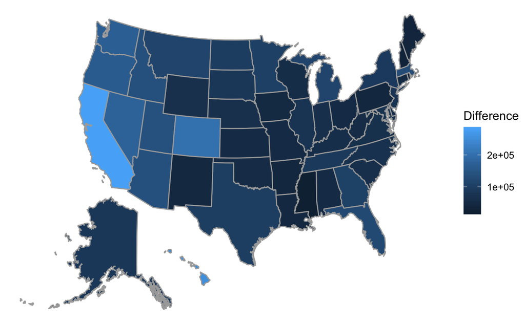

```r
USMap(data=MinMaxMeanPerState, key="RegionName", fill=Difference)
```

This graphic helps to show that there were more people moving out West after the housing crisis. The variable “Difference” is the difference between the cheapest house price of that state and the most expensive. As more people wanted to move out West, the demand for housing increased which increased the prices of homes more quickly. These people moving is what caused such a big difference in price. Whereas on the East coast and North-East there was not much change in price since people were not moving there. This was an interesting observation that I had not expected when going into the project.

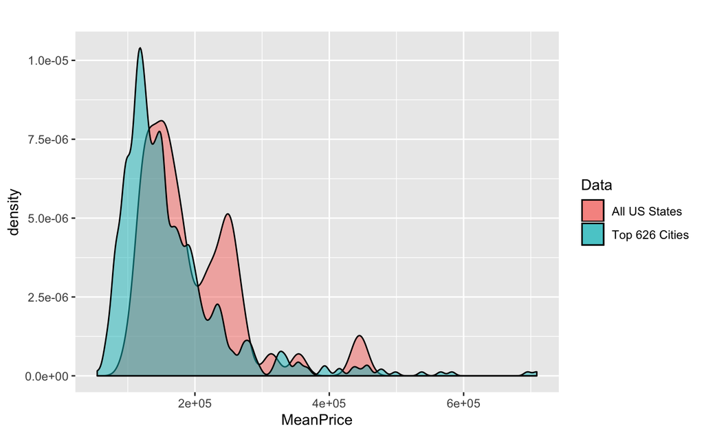

```r
ggplot( data = MinMaxMeanPerState, aes(x = MeanPrice,fill="All US States")) + geom_density(adjust = 0.38,alpha=.5)+labs(title = "")+geom_density(aes(x = MeanPrice,fill="Top 626 Cities"),MinMaxMeanPerCity,adjust = 0.38,alpha=.5)+guides(fill=guide_legend(title="Data"))
```

This graphic is one that helps to show the density of mean prices. Again in the red we have the mean values of all the US states and in blue we have the mean value of the top 626 cities in the US. The mean prices of the cities increase faster than the states but then also drop off much faster. Whereas the mean prices of the states takes longer to increase but also remains at that point longer. This graphic is interesting because it shows that there are more, higher prices for houses throughout all the states when compared to the cities. The houses in cities lost their value whereas the houses in more remote areas held their value or even increased. This could have been due to people wanting to travel out West, to more rural areas and thus increasing the prices of those homes. Those 2 supporting observations can be seen in the previous 2 graphs.

```r
# Splits up the 50 states into the 10 most and 10 least populated states
top <- SalePricesState %>% filter(SizeRank!=3) %>% head(10) %>% mutate(Size="Most populated states")
bot <- SalePricesState %>% filter(SizeRank!=41, SizeRank!=42, SizeRank!=43) %>% tail(10) %>% mutate(Size="Least populated states")
TopBot <- rbind(top,bot)

# This function goes through each row and finds out when the average price of houses rose above the initial value in March of 2008
new <- c("")
for (i in 1:nrow(TopBot)) {
  first <- TopBot[[4]]
  for (j in 10:ncol(TopBot)) {
    Second <- TopBot[[j]]
    if(Second[i]>=first[i]){
      new <- c(new,colnames(TopBot)[j])
      break
    } else if (j==142){
      new <- c(new,colnames(TopBot)[j])
      break
    }
  }
}
new <- new[-1]
new <- data.frame(second=new) %>% mutate(second = lubridate::dym(second))

# This finds the amount of years it took for the price to recover back to its original amount
FirstSecMonth <- TopBot %>% select(RegionName,Size) %>% mutate(first = lubridate::dym("2008-03"))
FirstSecMonth <- cbind(FirstSecMonth,new)
FirstSecMonth <- FirstSecMonth %>% mutate(Years = as.numeric(second-first)/365)
head(FirstSecMonth)
```

|  | RegionName | Size | first | second | Years |
| --- | --- | --- | --- | --- | --- |
| 1 | California | Most populated states | 2008-03-20 | 2015-04-20 | 7.087671 |
| 2 | Texas | Most populated states | 2008-03-20 | 2009-07-20 | 1.334247 |
| 3 | Florida | Most populated states | 2008-03-20 | 2018-01-20 | 9.843836 |
| 4 | Illinois | Most populated states | 2008-03-20 | 2019-09-20 | 11.509589 |
| 5 | Pennsylvania | Most populated states | 2008-03-20 | 2016-02-20 | 7.926027 |
| 6 | Ohio | Most populated states | 2008-03-20 | 2014-07-20 | 6.336986 |

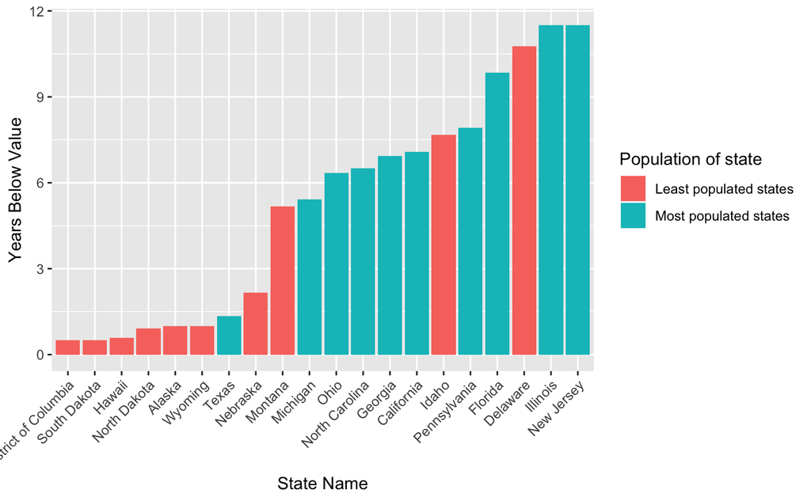

```r
FirstSecMonth %>% ggplot(aes(x=reorder(RegionName,Years),y=Years ,fill=Size))+geom_bar(stat='identity',position='dodge', width=.9) + theme(axis.text.x=element_text(angle=45,hjust=1))  +xlab("State Name")+ylab("Years Below Value")+guides(fill=guide_legend(title="Population of state"))
```

Now the final graphic. I split the 50 States into the 10 most and 10 least populated, then set the average house price in March, 2008 as the baseline value. The time it took for the average price of a house to again reach that baseline value, after decreasing significantly, was calculated for each state. The reason that I wanted to divide up the states into the most and least populated was to show how the housing crisis impacted different types of states. As you can clearly see from the graphic, houses in the least populated states spent a minimal amount of time on the market with 6/10 of those states having an average time of less than or equal a year. What this means is that the value of houses in these states did not decrease in value that much, and bounced right back up after the recession. One reason for this is that people moved out to rural, less populated states and drove up the housing prices from demand. This supports my earlier idea that people were attempting to move away from the cities and suburbs and move towards more rural areas which allowed for these rural housing markets to recover more quickly.

## Conclusion

**What factors impacted the recovery in different US States after the 2007-08 market crash?**

It seems like the population size of the state and where it was located impacted the prices of houses the host. The least populated, and most rural states saw a quicker recovery of their house prices from when they hit their lowest point. This is due to people heading out to these states in search of cheaper housing, and thus driving up the price.

**How have prices changed since then?**

Prices bottomed around the second half of 2011 dropping significantly in value. After this they have increased at a slower rate steadily. There seemed to be a quicker recovery in the rest of the US when just compared to its top cities. This observation could be due to people leaving the cities since they lost their jobs and looking for cheaper housing else where.

**Does location have any impact on the recovery of housing prices?**

Location did seem to have an impact, with the Western US having the biggest difference in house prices. Like earlier observations, this is due to people moving out west in search of more affordable housing. Whereas the North and North-East did not see that large of a difference in their prices post-bottoming out.